# Avances Proyecto 3: Descripcion Variables

Andre Jo 22199 Jose Prince 22087 Nelson Escalante 22046

2025-03-24

```r
datos <- read.csv("merged_output.csv")

head(datos)
```

```
##   DEPREG MUPREG MESREG AÑOREG DIAOCU MESOCU AÑOOCU DEPOCU MUPOCU EDADHOM
## 1      1    101      8   2015     17      7   2015     13   1301     999
## 2      1    101      6   2016     29      7   2015      1    101     999
## 3     19   1901      2   2016      8      7   2015     19   1901      46
## 4      1    101      2   2016     22     12   2015      1    115     999
## 5     22   2204      2   2015      3      2   2015     22   2206     999
## 6      1    101      6   2016     14     10   2015     22   2201     999
##   EDADMUJ PUEHOM PUEMUJ NACHOM NACMUJ ESCHOM ESCMUJ CIUOHOM CIUOMUJ
## 1     999      9      9    320    320      1      9    99.0    23.0
## 2     999      9      9    840    320      1      9    99.0    41.0
## 3      40      4      4    320    320      1      9    99.0    98.0
## 4     999      9      9    320    320      1      9    99.0    98.0
## 5     999      4      4    320    320      1      9    99.0    99.0
## 6     999      9      9    320    320      1      9    99.0    99.0
```

```r
colnames(datos)
```

```
##  [1] "DEPREG"  "MUPREG"  "MESREG"  "AÑOREG"  "DIAOCU"  "MESOCU"  "AÑOOCU"
##  [8] "DEPOCU"  "MUPOCU"  "EDADHOM" "EDADMUJ" "PUEHOM"  "PUEMUJ"  "NACHOM"
## [15] "NACMUJ"  "ESCHOM"  "ESCMUJ"  "CIUOHOM" "CIUOMUJ"
```

Descripción de Variables

Variable Categórica DEPREG - Departamento de registro  
Representa el departamento en el cual se registró el evento (1-22)

Variable Categórica MUPREG - Municipio de registro Representa el municipio en el cual se registró el evento ( 0101-2217 )

Variable Númerica MESREG - Mes de registro Representa el mes en el cual se registró el evento (1-12)

Variable Númerica AÑOREG - Año de registro es representado desde (2012-2024)

Variable Númerica MESOCU - Mes de ocurrencia (1-12)

Variable Categórica DEPOCU - Departamento de Ocurrencia (1-22)

Variable Categórica MUPOCU - Municipio de ocurrencia ( 0101-2217 ) Lugar que ocurrio el divorcio

Variable Númerica EDADHOM - Edad del hombre rango de 1-100 año y 999 como ignorado

Variable Númerica EDADMUJ - Edad de la Mujer rango de 1-100 año 999 como ignorado

Variable Categórica PUEHOM - Pueblo de pertenencia del hombre (1-5), 9 is ignorado Es la etnia que pertenece si es Maya, Garifuna o Xinca entre otros.

Variable Categórica PUEMUJ - Pueblo de pertenencia de la mujer (1-5), 9 is ignorado Es la etnia que pertenece si es Maya, Garifuna o Xinca entre otros.

Variable Categórica NACHOM - Nacionalidad del hombre (argentina, peru, Guatemala, Venezuela etc..) Denotados por números aunque se observa que 9999 representa valor ignorado

Variable Categórica NACMUJ - Nacionalidad de la mujer (argentina, peru, Guatemala, Venezuela etc..) Denotados por números aunque se observa que 9999 representa valor ignorado

Variable Categórica ESCHOM - Escolaridad del hombre rango de 1 a 6 siendo 1 ninguno y 6 postgrado 9 es ignorado

Variable Categórica ESCMUJ - Escolaridad de la mujer rango de 1 a 6 siendo 1 ninguno y 6 postgrado 9 es ignorado

Variable Categórica CIUOHOM - Ocupación (Subgrupos, CIUO-08) del hombre Ocupación (trabajo) denotado por 01-96 del otro lado se pone IGNORADO y en caso no estar especificado se pone NEOG

Variable Categórica CIUOMUJ - Ocupación (Subgrupos, CIUO-08) de la mujer Ocupación (trabajo) denotado por 01-96 del otro lado se pone IGNORADO y en caso no estar especificado se pone NEOG

Tomar nota que hay unas discrepancias con las ocupaciones en la lista de variables ya que hay algunos archivos en EXCEL que utilizaron codigo de 4 digitos y otros de 2 digitos. Por otro lado si no se encuentra de la lista se tomara en cuenta como otro etiqueta 97 No especificado en otro grupo Por otro lado si hay 9999 se tomara como IGNORADO

Se observa tambien que las variables estan denotadas por codigo lo cual se tiene que utilizar excel de definicion de variables para saber la etiqueta.

```r
length(colnames(datos))
```

```
## [1] 19
```

```r
nrow(datos)
```

```
## [1] 81826
```

```r
summary(datos)
```

```
##      DEPREG           MUPREG           MESREG           AÑOREG
##  Min.   : 1.000   Min.   : 101.0   Min.   : 1.000   Min.   :2012
##  1st Qu.: 1.000   1st Qu.: 101.0   1st Qu.: 4.000   1st Qu.:2015
##  Median : 6.000   Median : 601.0   Median : 7.000   Median :2019
##  Mean   : 7.815   Mean   : 786.5   Mean   : 6.546   Mean   :2018
##  3rd Qu.:13.000   3rd Qu.:1304.0   3rd Qu.:10.000   3rd Qu.:2022
##  Max.   :22.000   Max.   :2217.0   Max.   :12.000   Max.   :2024
##
##      DIAOCU          MESOCU           AÑOOCU          DEPOCU
##  Min.   : 1.00   Min.   : 1.000   Min.   :2015    Min.   : 1.000
##  1st Qu.: 8.00   1st Qu.: 3.000   1st Qu.:2017    1st Qu.: 1.000
##  Median :16.00   Median : 6.000   Median :2020    Median : 6.000
##  Mean   :15.78   Mean   : 6.305   Mean   :2020    Mean   : 8.025
##  3rd Qu.:23.00   3rd Qu.: 9.000   3rd Qu.:2022    3rd Qu.:13.000
##  Max.   :31.00   Max.   :12.000   Max.   :2023    Max.   :22.000
##                                   NA's   :16274
##      MUPOCU        EDADHOM         EDADMUJ          PUEHOM          PUEMUJ
##  Min.   : 101   Min.   : 15.0   Min.   : 15.0   Min.   :1.000   Min.   :1.000
##  1st Qu.: 102   1st Qu.: 33.0   1st Qu.: 31.0   1st Qu.:4.000   1st Qu.:4.000
##  Median : 613   Median : 54.0   Median : 49.0   Median :9.000   Median :9.000
##  Mean   : 808   Mean   :484.1   Mean   :481.5   Mean   :6.279   Mean   :6.303
##  3rd Qu.:1317   3rd Qu.:999.0   3rd Qu.:999.0   3rd Qu.:9.000   3rd Qu.:9.000
##  Max.   :2217   Max.   :999.0   Max.   :999.0   Max.   :9.000   Max.   :9.000
##
##      NACHOM           NACMUJ           ESCHOM          ESCMUJ
##  Min.   :  10.0   Min.   :  32.0   Min.   :0.000   Min.   :0.00
##  1st Qu.: 320.0   1st Qu.: 320.0   1st Qu.:3.000   1st Qu.:3.00
##  Median : 320.0   Median : 320.0   Median :5.000   Median :4.00
##  Mean   : 361.6   Mean   : 362.5   Mean   :5.659   Mean   :5.62
##  3rd Qu.: 320.0   3rd Qu.: 320.0   3rd Qu.:9.000   3rd Qu.:9.00
##  Max.   :9999.0   Max.   :9999.0   Max.   :9.000   Max.   :9.00
##
##    CIUOHOM            CIUOMUJ
##  Length:81826       Length:81826
##  Class :character   Class :character
##  Mode  :character   Mode  :character
##
##
##
##
```

# Exploración variables númericas

Se tienen las siguientes variables como númericas:

- **AÑOREG** - Año de registro
- **DIAOCU** - Día de ocurrencia
- **MESOCU** - Mes de ocurrencia
- **AÑOOCU** - Año de ocurrencia
- **EDADHOM** - Edad del hombre
- **EDADMUJ** - Edad de la mujer

```r
datos <- read.csv("merged_output.csv")

media_EDADHOM <- mean(datos$EDADHOM[datos$EDADHOM != 999], na.rm = TRUE)
media_EDADMUJ <- mean(datos$EDADMUJ[datos$EDADMUJ != 999], na.rm = TRUE)

datos$EDADHOM[datos$EDADHOM == 999] <- media_EDADHOM
datos$EDADMUJ[datos$EDADMUJ == 999] <- media_EDADMUJ


datos_numericos <- datos[, c("AÑOREG", "DIAOCU", "MESOCU", "AÑOOCU", "EDADHOM", "EDADMUJ")]

calcular_estadisticas <- function(columna) {
  lista <- list(
    Media = mean(columna, na.rm = TRUE),
    Mediana = median(columna, na.rm = TRUE),
    Moda = as.numeric(names(sort(table(columna), decreasing = TRUE)[1])),
    Rango = range(columna, na.rm = TRUE),
    Varianza = var(columna, na.rm = TRUE),
    Desviacion_Estandar = sd(columna, na.rm = TRUE),
    Minimo = min(columna, na.rm = TRUE),
    Q1 = quantile(columna, 0.25, na.rm = TRUE),
    Q2 = quantile(columna, 0.50, na.rm = TRUE),
    Q3 = quantile(columna, 0.75, na.rm = TRUE),
    Maximo = max(columna, na.rm = TRUE)
  )
  return(lista)
}

estadisticas <- lapply(datos_numericos, calcular_estadisticas)

for (variable in names(estadisticas)) {
  cat("\n", variable, "\n")
  for (nombre_estadistica in names(estadisticas[[variable]])) {
    cat(nombre_estadistica, ":", estadisticas[[variable]][[nombre_estadistica]], "\n")
  }
}
```

```
##
##  AÑOREG
## Media : 2018.461
## Mediana : 2019
## Moda : 2023
## Rango : 2012 2024
## Varianza : 12.3628
## Desviacion_Estandar : 3.516078
## Minimo : 2012
## Q1 : 2015
## Q2 : 2019
## Q3 : 2022
## Maximo : 2024
##
##  DIAOCU
## Media : 15.77667
## Mediana : 16
## Moda : 22
## Rango : 1 31
## Varianza : 75.38634
## Desviacion_Estandar : 8.68253
## Minimo : 1
## Q1 : 8
## Q2 : 16
## Q3 : 23
## Maximo : 31
##
##  MESOCU
## Media : 6.304646
## Mediana : 6
## Moda : 3
## Rango : 1 12
## Varianza : 10.89804
## Desviacion_Estandar : 3.301217
## Minimo : 1
## Q1 : 3
## Q2 : 6
## Q3 : 9
## Maximo : 12
##
```

[output cut: 23 more lines]

```
## Q3 : 36.31324
## Maximo : 98
##
##  EDADMUJ
## Media : 33.14645
## Mediana : 33.14645
## Moda : 33.14645
## Rango : 15 81
## Varianza : 44.62304
## Desviacion_Estandar : 6.680048
## Minimo : 15
## Q1 : 31
## Q2 : 33.14645
## Q3 : 33.14645
## Maximo : 81
```

```r
library(tidyr)
```

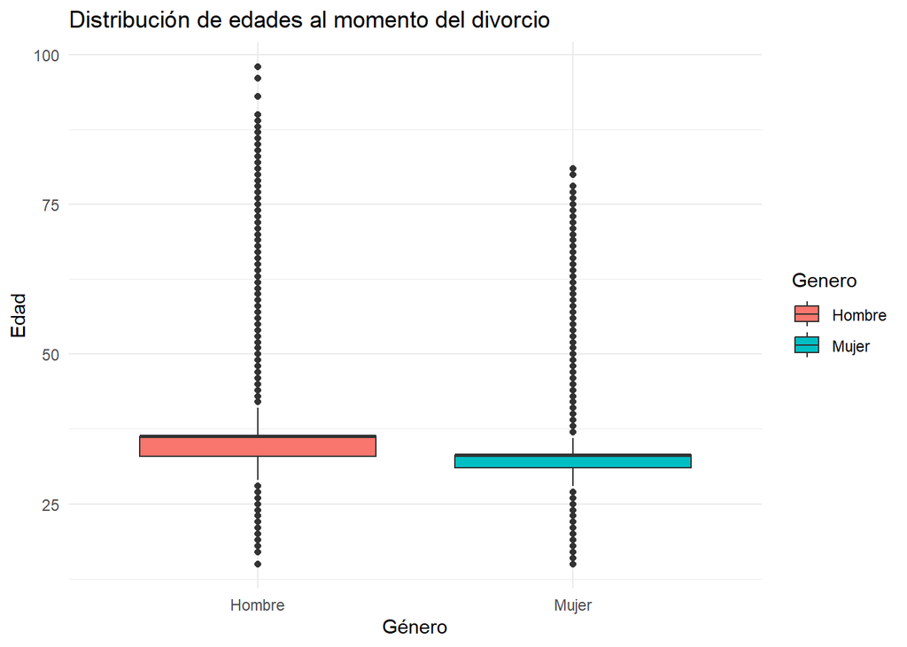

```r
datos_num_mod <- datos_numericos %>%
  select(EDADHOM, EDADMUJ) %>%
  pivot_longer(cols = everything(), names_to = "Genero", values_to = "Edad") %>%
  mutate(Genero = recode(Genero, EDADHOM = "Hombre", EDADMUJ = "Mujer"))

ggplot(datos_num_mod, aes(x = Genero, y = Edad, fill = Genero)) +
  geom_boxplot() +
  labs(
    title = "Distribución de edades al momento del divorcio",
    x = "Género",
    y = "Edad"
  ) +
  theme_minimal()
```

El análisis de las variables numéricas revela tendencias significativas en los datos. Para las fechas de registro y ocurrencia (AÑOREG y AÑOOCU), se observa que la media y la mediana están cerca de 2019, lo que indica que la mayoría de los eventos se registraron en años recientes. La moda en ambos casos es 2023, lo que sugiere un aumento en los registros en ese año. La dispersión de los datos es baja, con desviaciones estándar de 3.52 y 2.61 respectivamente, lo que implica que la mayoría de los valores se concentran en torno a la media. EN cuanto a los días y meses de ocurrencia (DIAOCU y MESOCU), la distribución parece uniforme, con valores centrales en torno al día 16 y al mes 6. La desviación estándar en el día de ocurrencia es de 8.68, lo que indica mayor variabilidad en los días en comparación con los meses.

Respecto a las edades (EDADHOM y EDADMUJ), las medias son de aproximadamente 36 y 33 años respectivamente, con una dispersión relativamente baja. Esto sugiere que la mayoría de los registros corresponden a adultos jóvenes (este dato debe ser corroborado debido a la omisión de muchas edades en el dataset). El rango de los hombres es mayor (15 - 98 años) en comparación con el de las mujeres (15 - 81 años), lo que podría reflejar una mayor presencia de hombres de mayor edad en los registros. En general, la distribución de las edades es relativamente homogénea.

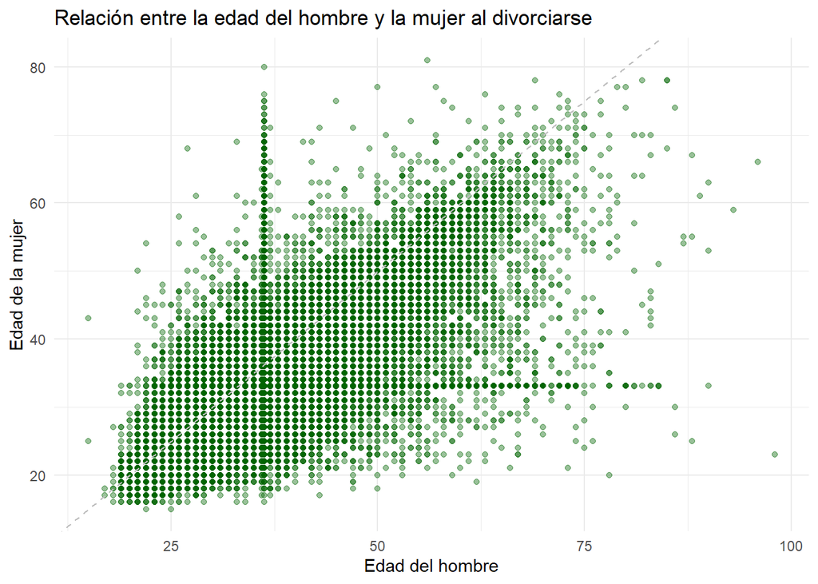

```r
ggplot(datos_numericos, aes(x = EDADHOM, y = EDADMUJ)) +
  geom_point(alpha = 0.4, color = "darkgreen") +
  geom_abline(slope = 1, intercept = 0, color = "gray", linetype = "dashed") +
  labs(
    title = "Relación entre la edad del hombre y la mujer al divorciarse",
    x = "Edad del hombre",
    y = "Edad de la mujer"
  ) +
  theme_minimal()
```

A traves del grafico de dispersion se puede observar con mayor detalle la relacion entre las edades de los hombres y las mujeres divorciados en el conjunto de datos. La linea de identidad nos ayuda a identificar de manera mas visual que las edades de los hombres suelen ser mayores que las de las mujeres. Cabe notar que aproximadamente antes de los 35 años, las edades entre las personas son similares, y luego de este numero las edades de los hombres suele aumenta en relacion a las de las mujeres; esto se puede observar ya que la mayoria de los datos pasados los 35 años se encuentran debajo de la linea de identidad.

# Exploración variables categoricas

Se tienen las siguientes variables como categóricas:

- **DEPREG** - Departamento de registro
- **MUPREG** - Municipio de registro
- **MESREG** - Mes de registro
- **DEPOCU** - Departamento de ocurrencia
- **MUPOCU** - Municipio de ocurrencia
- **PUEHOM** - Pueblo de pertenencia del hombre
- **PUEMUJ** - Pueblo de pertenencia de la mujer
- **NACHOM** - Nacionalidad del hombre
- **NACMUJ** - Nacionalidad de la mujer
- **ESCHOM** - Escolaridad del hombre
- **ESCMUJ** - Escolaridad de la mujer
- **CIUOHOM** - Ocupación del hombre (según CIUO-08)
- **CIUOMUJ** - Ocupación de la mujer (según CIUO-08)

```r
datos_categoricos <- datos[, c("DEPREG", "MUPREG", "DEPOCU", "MUPOCU", "PUEHOM", "PUEMUJ", "NACHOM", "NACMUJ", "ESCHOM", "ESCMUJ", "CIUOHOM", "CIUOMUJ")]
```

Para entender mejor los datos, se decodificaran algunas de las variables categoricas para mejorar la legibilidad.

```r
dep_decod <- c(
  "1" = "Guatemala",
  "2"   = "El Progreso",
  "3" = "Sacatepéquez",
  "4" = "Chimaltenango",
  "5" = "Escuintla",
  "6" = "Santa Rosa",
  "7" = "Sololá",
  "8" = "Totonicapán",
  "9"   = "Quetzaltenango",
  "10" = "Suchitepéquez",
  "11" = "Retalhuleu",
  "12" = "San Marcos",
  "13" = "Huehuetenango",
  "14" = "Quiché",
  "15" = "Baja Verapaz",
  "16" = "Alta Verapaz",
  "17" = "Petén",
  "18" = "Izabal",
  "19" = "Zacapa",
  "20" = "Chiquimula",
  "21" = "Jalapa",
  "22" = "Jutiapa"
)

pue_decod <- c(
"1" = "Maya",
"2" = "Garífuna",
"3" = "Xinka",
"4" = "Mestizo / Ladino",
"5" = "Otro",
"9" = "Ignorado"
)

esc_decod <- c(
"1" = "Ninguno",
"2" = "Primaria",
"3" = "Básica",
"4" = "Diversificado",
"5" = "Universitario",
"6" = "Postgrado",
"9" = "Ingorado"
)

datos_categoricos <- datos_categoricos %>%
  mutate(
    DEPREG = dep_decod[as.character(DEPREG)],
    DEPOCU = dep_decod[as.character(DEPOCU)],
    PUEHOM = pue_decod[as.character(PUEHOM)],
    PUEMUJ = pue_decod[as.character(PUEMUJ)],
    ESCHOM = esc_decod[as.character(ESCHOM)],
    ESCMUJ = esc_decod[as.character(ESCMUJ)],
  )
```

Las variables que se decodificaron fueron seleccionadas debido a que estas son relevantes para enteder los datos a simple vista. Las variables de nacionalidad, municipio y ocupacion no fueron decodificadas debido a la cantidad de datos en estas, los cuales, al decodificar, podrian causar complicaciones en la legibilidad y comprension de los datos.

```r
generar_tabla_frecuencia <- function(columna) {
  tabla <- table(columna)
  return(tabla)
}

tablas_frecuencia <- head(lapply(datos_categoricos, generar_tabla_frecuencia),10)

for (variable in names(tablas_frecuencia)) {
  cat("\n", variable, "\n")
  print(tablas_frecuencia[[variable]])
}
```

```
##
##  DEPREG
## columna
##   Alta Verapaz   Baja Verapaz  Chimaltenango     Chiquimula    El Progreso
##           1731           1418           1801           2012           1485
##      Escuintla      Guatemala  Huehuetenango         Izabal         Jalapa
##           3598          31204           2792           2578           2029
##        Jutiapa          Petén Quetzaltenango         Quiché     Retalhuleu
##           2982           2356           6827           2239           2460
##   Sacatepéquez     San Marcos     Santa Rosa         Sololá  Suchitepéquez
##           1760           3251           2257            952           2891
##    Totonicapán         Zacapa
##           1287           1916
##
##  MUPREG
```

[output cut: 177 more lines]

El análsis de las tablas de frecuencia de DEPREG y MUPREG revela una distribución desigual de los datos. En DEPREG, la categoría con mayor frecuencia es la primera, con 31,204 casos, lo que representa una concentración significativa en comparación con las demás. Otras categorías muestran una distribución más dispersa, con valores que oscilan entre 952 y 6,827, lo que sugiere una fuerte asimetría en los datos. Este patrón indica que la mayoría de los registros pertenecen a una sola categoría, mientras que las demás están distribuidas en menor medida.

Por otro lado, MUPREG presenta una ayor dispersión con un número más elevado de categorías, algunas con muy pocos registros. La categoría más frecuente (101) tiene 23,848 casos, superando ampliamente a las demás, mientras que muchas otras tienen frecuencias menores a 1,000. Esto sugiere que ciertos valores dominan la distribución mientras que la mayoría son poco representativos. La alta variabilidad en la distribución de frecuencia indica la necesidad de un análisis más profundo para comprender la relevancia de cada categoría y su impacto en el conjunto de datos.

```r
datos <- read.csv("merged_output.csv")
```

Se estaran utilizando las siguientes variables para realizar un analisis categorico: “DEPREG”, “MUPREG”, “DEPOCU”, “MUPOCU”,“PUEHOM”, “PUEMUJ”, “NACHOM”, “NACMUJ”,“ESCHOM”, “ESCMUJ”, “CIUOHOM”, “CIUOMUJ”

```r
datos_categoricos <- datos[, c("DEPREG", "MUPREG", "DEPOCU", "MUPOCU",
                               "PUEHOM", "PUEMUJ", "NACHOM", "NACMUJ",
                               "ESCHOM", "ESCMUJ", "CIUOHOM", "CIUOMUJ")]

head(datos_categoricos)
```

```
##   DEPREG MUPREG DEPOCU MUPOCU PUEHOM PUEMUJ NACHOM NACMUJ ESCHOM ESCMUJ CIUOHOM
## 1      1    101     13   1301      9      9    320    320      1      9    99.0
## 2      1    101      1    101      9      9    840    320      1      9    99.0
## 3     19   1901     19   1901      4      4    320    320      1      9    99.0
## 4      1    101      1    115      9      9    320    320      1      9    99.0
## 5     22   2204     22   2206      4      4    320    320      1      9    99.0
## 6      1    101     22   2201      9      9    320    320      1      9    99.0
##   CIUOMUJ
## 1    23.0
## 2    41.0
## 3    98.0
## 4    98.0
## 5    99.0
## 6    99.0
```

## Cuantos registros de divorcios hay en cada departamento?

```r
freq_table <- as.data.frame(table(datos$DEPREG))
colnames(freq_table) <- c("DEPREG", "Frecuencia")
print(head(freq_table))
```

```
##   DEPREG Frecuencia
## 1      1      31204
## 2      2       1485
## 3      3       1760
## 4      4       1801
## 5      5       3598
## 6      6       2257
```

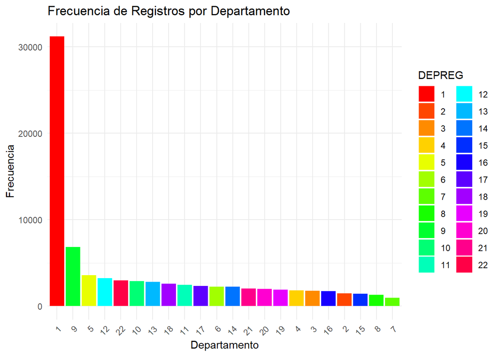

```r
# Plot with different colors for each category
ggplot(freq_table, aes(x = reorder(DEPREG, -Frecuencia), y = Frecuencia, fill = DEPREG)) +
  geom_bar(stat = "identity") +
  theme_minimal() +
  labs(title = "Frecuencia de Registros por Departamento",
       x = "Departamento",
       y = "Frecuencia") +
  theme(axis.text.x = element_text(angle = 45, hjust = 1)) +  # Rotate labels
  scale_fill_manual(values = rainbow(nrow(freq_table)))  # Different colors
```

1 Guatemala 2 El Progreso 3 Sacatepéquez 4 Chimaltenango 5 Escuintla 6 Santa Rosa 7 Sololá 8 Totonicapán 9 Quetzaltenango 10 Suchitepéquez 11 Retalhuleu 12 San Marcos 13 Huehuetenango 14 Quiché 15 Baja Verapaz 16 Alta Verapaz 17 Petén 18 Izabal 19 Zacapa 20 Chiquimula 21 Jalapa 22 Jutiapa

Con estos datos posiblemente podemos realizar un analisis ante la relación entre el pueblo o etnia de las personas divorciadas y el departamento donde se registró el divorcio.

```r
freq_table <- as.data.frame(table(datos$MUPREG))
colnames(freq_table) <- c("MUPREG", "Frecuencia")
print(head(freq_table))
```

```
##   MUPREG Frecuencia
## 1    101      23848
## 2    102        354
## 3    103        345
## 4    104        142
## 5    105        134
## 6    106        589
```

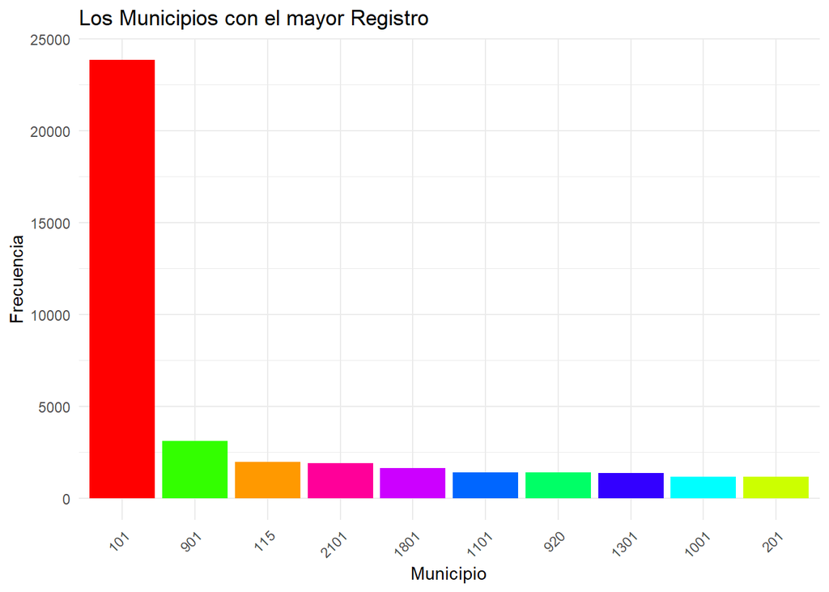

```r
freq_table <- freq_table %>%
  arrange(desc(Frecuencia)) %>%
  head(10)

# Plot with different colors for each category
ggplot(freq_table, aes(x = reorder(MUPREG, -Frecuencia), y = Frecuencia, fill = MUPREG)) +
  geom_bar(stat = "identity") +
  theme_minimal() +
  labs(title = "Los Municipios con el mayor Registro ",
       x = "Municipio",
       y = "Frecuencia") +
  theme(axis.text.x = element_text(angle = 45, hjust = 1), legend.position = "none") +  # Rotate labels
  scale_fill_manual(values = rainbow(nrow(freq_table)))  # Different colors
```

## Que departamento es más frecuente en registrar la ocurrencia del divorcio.

```r
freq_table <- as.data.frame(table(datos$DEPOCU))
colnames(freq_table) <- c("DEPOCU", "Frecuencia")
print(head(freq_table))
```

```
##   DEPOCU Frecuencia
## 1      1      29942
## 2      2       1454
## 3      3       1712
## 4      4       1761
## 5      5       3993
## 6      6       2320
```

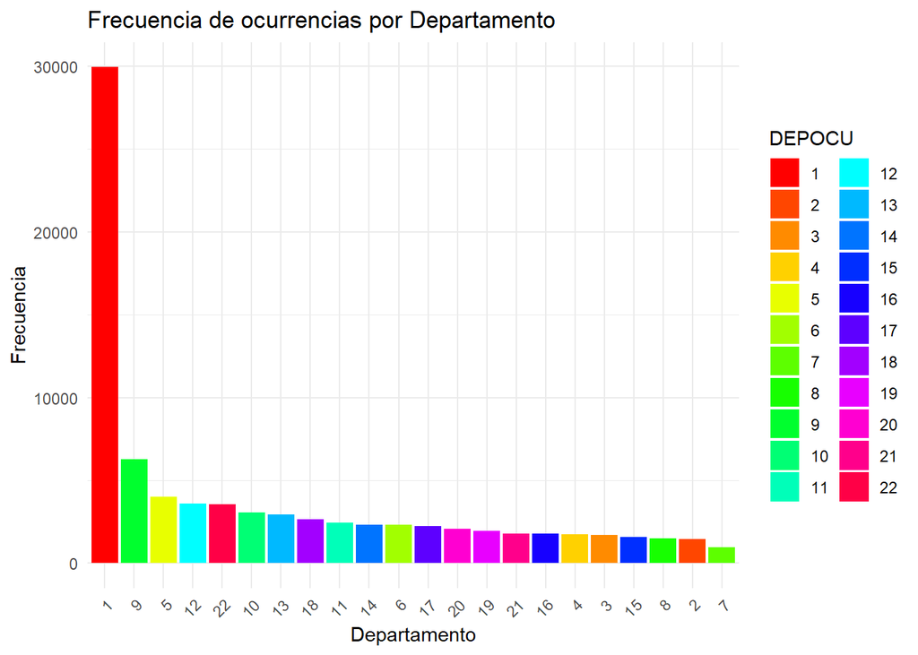

```r
# Plot with different colors for each category
ggplot(freq_table, aes(x = reorder(DEPOCU, -Frecuencia), y = Frecuencia, fill = DEPOCU)) +
  geom_bar(stat = "identity") +
  theme_minimal() +
  labs(title = "Frecuencia de ocurrencias por Departamento",
       x = "Departamento",
       y = "Frecuencia") +
  theme(axis.text.x = element_text(angle = 45, hjust = 1)) +  # Rotate labels
  scale_fill_manual(values = rainbow(nrow(freq_table)))  # Different colors
```

Frecuencia de los municipios con mayor ocurrencia

```r
freq_table <- as.data.frame(table(datos$MUPOCU))
colnames(freq_table) <- c("MUPOCU", "Frecuencia")
print(head(freq_table))
```

```
##   MUPOCU Frecuencia
## 1    101      20197
## 2    102        468
## 3    103        433
## 4    104        105
## 5    105        191
## 6    106        518
```

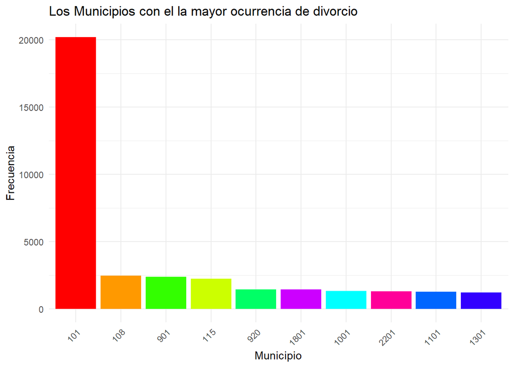

```r
freq_table <- freq_table %>%
  arrange(desc(Frecuencia)) %>%
  head(10)

# Plot with different colors for each category
ggplot(freq_table, aes(x = reorder(MUPOCU, -Frecuencia), y = Frecuencia, fill = MUPOCU)) +
  geom_bar(stat = "identity") +
  theme_minimal() +
  labs(title = "Los Municipios con el la mayor ocurrencia de divorcio ",
       x = "Municipio",
       y = "Frecuencia") +
  theme(axis.text.x = element_text(angle = 45, hjust = 1), legend.position = "none") +  # Rotate labels
  scale_fill_manual(values = rainbow(nrow(freq_table)))  # Different colors
```

Se confirma también cómo, en el departamento, tienen diferentes datos los registros y las ocurrencias, lo cual indica que son variables diferentes. Sin embargo, lo que más se observa es que el municipio de Guatemala tiene la mayor frecuencia en la ocurrencia de divorcio.

## Frecuencia de etnias registrados por Hombre

```r
freq_table <- as.data.frame(table(datos$PUEHOM))
colnames(freq_table) <- c("PUEHOM", "Frecuencia")
print(freq_table)
```

```
##   PUEHOM Frecuencia
## 1      1       6291
## 2      2       1143
## 3      3         12
## 4      4      32369
## 5      5        609
## 6      9      41402
```

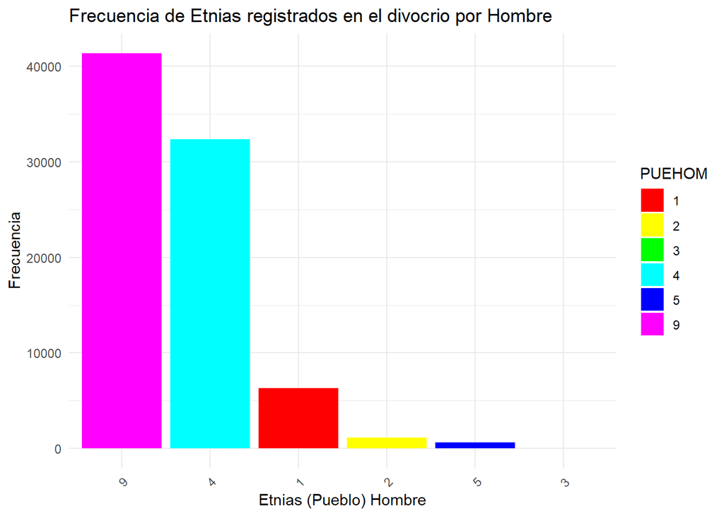

```r
# Plot with different colors for each category
ggplot(freq_table, aes(x = reorder(PUEHOM, -Frecuencia), y = Frecuencia, fill = PUEHOM)) +
  geom_bar(stat = "identity") +
  theme_minimal() +
  labs(title = "Frecuencia de Etnias registrados en el divocrio por Hombre",
       x = "Etnias (Pueblo) Hombre",
       y = "Frecuencia") +
  theme(axis.text.x = element_text(angle = 45, hjust = 1)) +  # Rotate labels
  scale_fill_manual(values = rainbow(nrow(freq_table)))  # Different colors
```

1 Maya 2 Garífuna 3 Xinka 4 Mestizo / Ladino 5 Otro 9 Ignorado

## Mujer

```r
freq_table <- as.data.frame(table(datos$PUEMUJ))
colnames(freq_table) <- c("PUEMUJ", "Frecuencia")
print(freq_table)
```

```
##   PUEMUJ Frecuencia
## 1      1       5820
## 2      2       1171
## 3      3         16
## 4      4      32621
## 5      5        687
## 6      9      41511
```

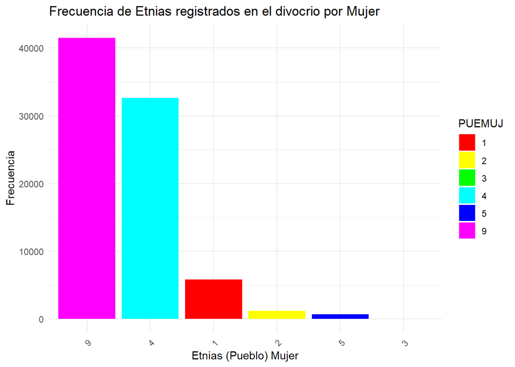

```r
# Plot with different colors for each category
ggplot(freq_table, aes(x = reorder(PUEMUJ, -Frecuencia), y = Frecuencia, fill = PUEMUJ)) +
  geom_bar(stat = "identity") +
  theme_minimal() +
  labs(title = "Frecuencia de Etnias registrados en el divocrio por Mujer",
       x = "Etnias (Pueblo) Mujer",
       y = "Frecuencia") +
  theme(axis.text.x = element_text(angle = 45, hjust = 1)) +  # Rotate labels
  scale_fill_manual(values = rainbow(nrow(freq_table)))  # Different colors
```

1 Maya 2 Garífuna 3 Xinka 4 Mestizo / Ladino 5 Otro 9 Ignorado

Se observa que la mayor frecuencia es IGNORADO aunque observamos en el segundo puesto que los Mestizos/Ladinos con un total de 32621 registros, luego estan Maya y la menor frecuencia, se encuentra el pueblo Xinka con un total de 16 registros.

## Nacionalidad de la Hombre

```r
freq_table <- as.data.frame(table(datos$NACHOM))
colnames(freq_table) <- c("NACHOM", "Frecuencia")
print(freq_table)
```

```
##    NACHOM Frecuencia
## 1      10          2
## 2      32         22
## 3      36          2
## 4      40          5
## 5      56          1
## 6      68          8
## 7      76          9
## 8      84          9
## 9     100          1
## 10    124         18
## 11    152         15
## 12    156         10
## 13    170         51
## 14    188         37
```

[output cut: 57 more lines]

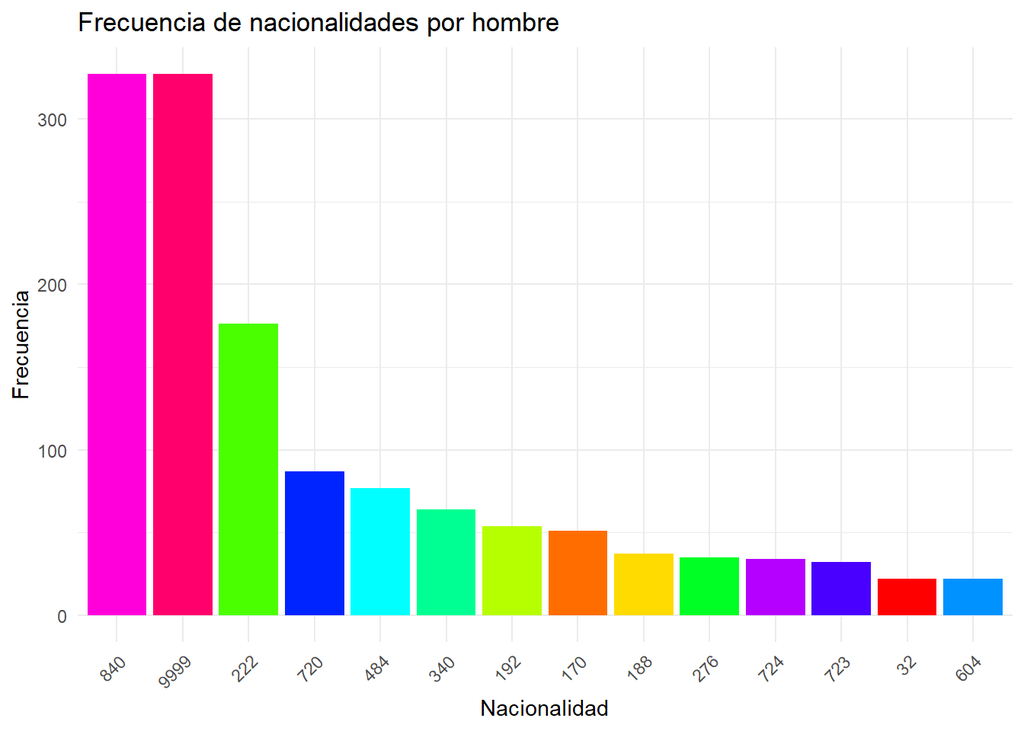

```r
freq_table <- freq_table %>%
  arrange(desc(Frecuencia)) %>%
  head(15)
freq_table <- freq_table %>%
  filter(NACHOM != "320")  # Removes the row with NACHOM equal to "320"


# Plot with different colors for each category
ggplot(freq_table, aes(x = reorder(NACHOM, -Frecuencia), y = Frecuencia, fill = NACHOM)) +
  geom_bar(stat = "identity") +
  theme_minimal() +
  labs(title = "Frecuencia de nacionalidades por hombre",
       x = "Nacionalidad",
       y = "Frecuencia") +
  theme(axis.text.x = element_text(angle = 45, hjust = 1), legend.position = "none") +  # Rotate labels
  scale_fill_manual(values = rainbow(nrow(freq_table)))  # Different colors
```

Tomar nota de que no se agregó la nacionalidad Guatemala debido a que sabemos que tiene un mayor porcentaje. Solo observaremos las de otras nacionalidades para ver cuál es la más frecuente. Se observa que Estados Unidos y la variable IGNORADO son las más frecuentes, ya que tienen 327 datos.

```r
freq_table <- as.data.frame(table(datos$NACMUJ))
colnames(freq_table) <- c("NACMUJ", "Frecuencia")
print(head(freq_table))
```

```
##   NACMUJ Frecuencia
## 1     32         15
## 2     36          1
## 3     40          2
## 4     56          3
## 5     68          1
## 6     76          9
```

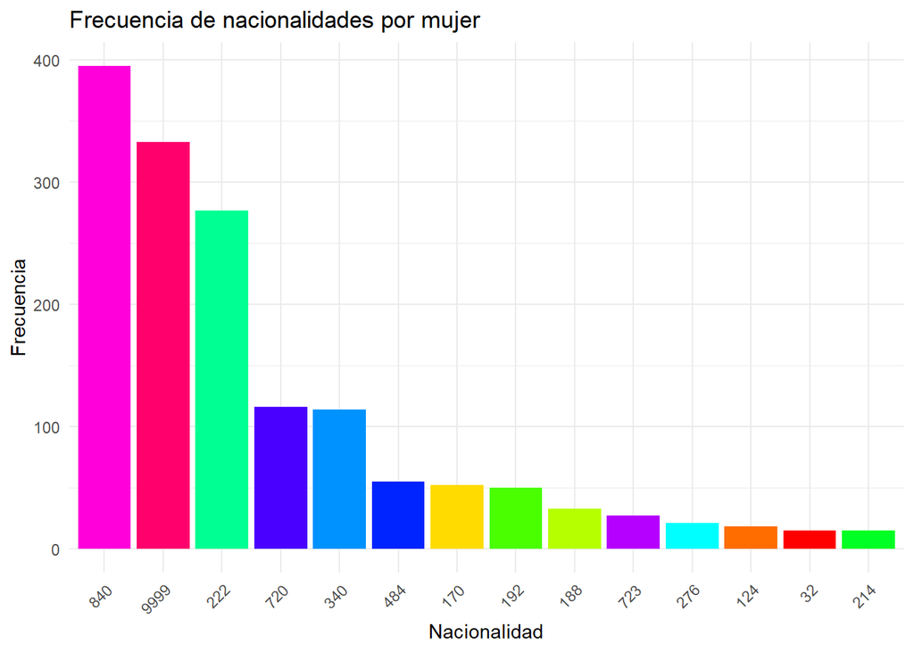

```r
freq_table <- freq_table %>%
  arrange(desc(Frecuencia)) %>%
  head(15)
freq_table <- freq_table %>%
  filter(NACMUJ != "320")  # Removes the row with NACHOM equal to "320"


# Plot with different colors for each category
ggplot(freq_table, aes(x = reorder(NACMUJ, -Frecuencia), y = Frecuencia, fill = NACMUJ)) +
  geom_bar(stat = "identity") +
  theme_minimal() +
  labs(title = "Frecuencia de nacionalidades por mujer",
       x = "Nacionalidad",
       y = "Frecuencia") +
  theme(axis.text.x = element_text(angle = 45, hjust = 1), legend.position = "none") +  # Rotate labels
  scale_fill_manual(values = rainbow(nrow(freq_table)))  # Different colors
```

Tomar nota de que no se agregó la nacionalidad Guatemala debido a que sabemos que tiene un mayor porcentaje. Solo observaremos las de otras nacionalidades para ver cuál es la más frecuente. Se observa que Estados Unidos es más frecuente que la variable IGNORADO lo cual hace la mayor frecuente nacionalidad.

## Exploración de la variable Escolaridad Hombre

```r
freq_table <- as.data.frame(table(datos$ESCHOM))
colnames(freq_table) <- c("ESCHOM", "Frecuencia")
print(freq_table)
```

```
##   ESCHOM Frecuencia
## 1      0        457
## 2      1       9660
## 3      2       7936
## 4      3       6334
## 5      4      15951
## 6      5       4542
## 7      6        157
## 8      9      36789
```

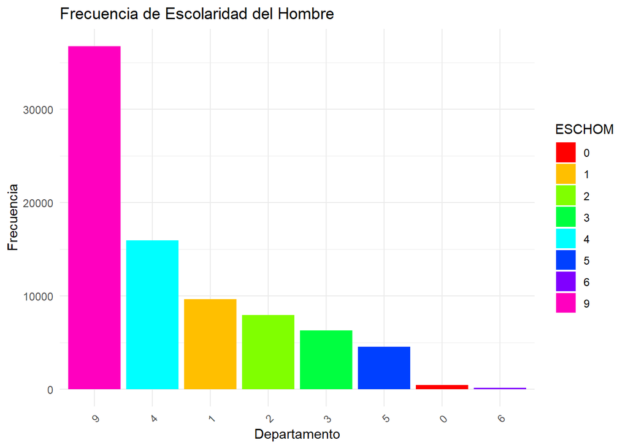

```r
# Plot with different colors for each category
ggplot(freq_table, aes(x = reorder(ESCHOM, -Frecuencia), y = Frecuencia, fill = ESCHOM)) +
  geom_bar(stat = "identity") +
  theme_minimal() +
  labs(title = "Frecuencia de Escolaridad del Hombre",
       x = "Departamento",
       y = "Frecuencia") +
  theme(axis.text.x = element_text(angle = 45, hjust = 1)) +  # Rotate labels
  scale_fill_manual(values = rainbow(nrow(freq_table)))  # Different colors
```

1 Ninguno 2 Primaria 3 Básica 4 Diversificado 5 Universitario 6 Postgrado 9 Ignorado

Se observa que la mayor frecuencia corresponde a la variable IGNORADO, lo cual no nos indica si la población está educada o no. Por otro lado, observamos que la variable ‘diversificado’ (15,951) es la más frecuente y tiene cierta significancia. Otro dato importante a resaltar es que la variable ‘ninguno’ es la tercera más frecuente, lo cual podríamos relacionar con la causa del divorcio, si esta está vinculada con la educación.

```r
freq_table <- as.data.frame(table(datos$ESCMUJ))
colnames(freq_table) <- c("ESCMUJ", "Frecuencia")
print(freq_table)
```

```
##   ESCMUJ Frecuencia
## 1      0        542
## 2      1      10067
## 3      2       7622
## 4      3       6275
## 5      4      16452
## 6      5       4401
## 7      6        109
## 8      9      36358
```

[figure not shown]

```r
# Plot with different colors for each category
ggplot(freq_table, aes(x = reorder(ESCMUJ, -Frecuencia), y = Frecuencia, fill = ESCMUJ)) +
  geom_bar(stat = "identity") +
  theme_minimal() +
  labs(title = "Frecuencia de Escolaridad del Hombre",
       x = "Departamento",
       y = "Frecuencia") +
  theme(axis.text.x = element_text(angle = 45, hjust = 1)) +  # Rotate labels
  scale_fill_manual(values = rainbow(nrow(freq_table)))  # Different colors
```

## Ocupacion Hombres

```r
replace_with_median <- function(df, column_name) {
  # Extract the first two digits from the specified column
  df <- df %>%
    mutate(!!column_name := as.integer(substr(as.character(!!sym(column_name)), 1, 2)))

  # Calculate the median of the transformed column
  median_value <- median(df[[column_name]], na.rm = TRUE)

  # Replace NA values with the median
  df[[column_name]][is.na(df[[column_name]])] <- median_value

  return(df)
}


datos <- replace_with_median(datos, "CIUOHOM")
datos <- replace_with_median(datos, "CIUOMUJ")
```

```r
freq_table <- as.data.frame(table(datos$CIUOHOM))
colnames(freq_table) <- c("CIUOHOM", "Frecuencia")
print(freq_table)
```

```
##    CIUOHOM Frecuencia
## 1        1         88
## 2        3         82
## 3       11         77
## 4       12        306
## 5       13         41
## 6       14          8
## 7       21       1195
## 8       22        602
## 9       23       2192
## 10      24        618
## 11      25        252
## 12      26        855
## 13      31       1581
## 14      32        208
```

[output cut: 30 more lines]

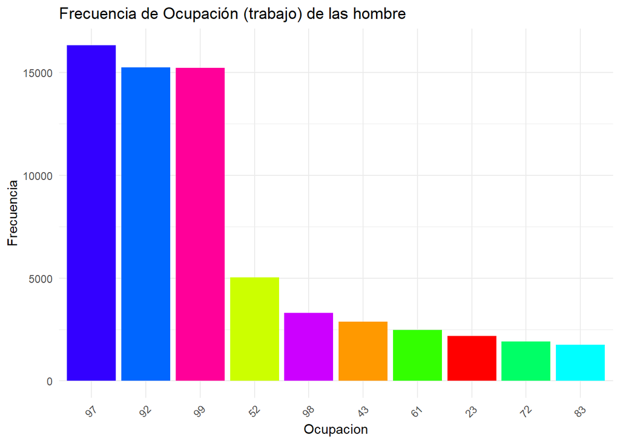

```r
freq_table <- freq_table %>%
  arrange(desc(Frecuencia)) %>%
  head(10)

# Plot with different colors for each category
ggplot(freq_table, aes(x = reorder(CIUOHOM, -Frecuencia), y = Frecuencia, fill = CIUOHOM)) +
  geom_bar(stat = "identity") +
  theme_minimal() +
  labs(title = "Frecuencia de Ocupación (trabajo) de las hombre ",
       x = "Ocupacion",
       y = "Frecuencia") +
  theme(axis.text.x = element_text(angle = 45, hjust = 1), legend.position = "none") +  # Rotate labels
  scale_fill_manual(values = rainbow(nrow(freq_table)))  # Different colors
```

```r
freq_table <- as.data.frame(table(datos$CIUOMUJ))
colnames(freq_table) <- c("CIUOMUJ", "Frecuencia")
print(freq_table)
```

```
##    CIUOMUJ Frecuencia
## 1        1          9
## 2        3          5
## 3       11         40
## 4       12        225
## 5       13          5
## 6       14         14
## 7       21        479
## 8       22        613
## 9       23       4591
## 10      24        533
## 11      25         55
## 12      26       1036
## 13      31        145
## 14      32        547
```

[output cut: 28 more lines]

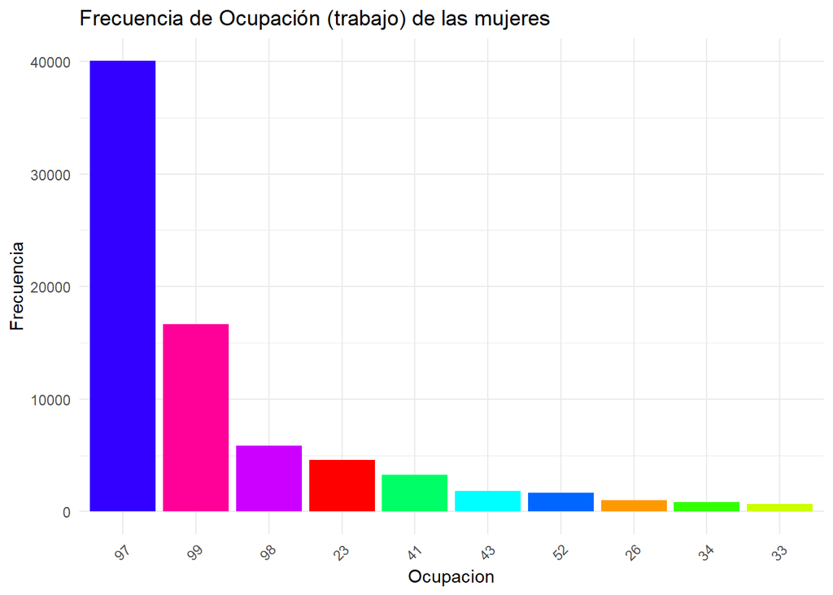

```r
freq_table <- freq_table %>%
  arrange(desc(Frecuencia)) %>%
  head(10)

# Plot with different colors for each category
ggplot(freq_table, aes(x = reorder(CIUOMUJ, -Frecuencia), y = Frecuencia, fill = CIUOMUJ)) +
  geom_bar(stat = "identity") +
  theme_minimal() +
  labs(title = "Frecuencia de Ocupación (trabajo) de las mujeres ",
       x = "Ocupacion",
       y = "Frecuencia") +
  theme(axis.text.x = element_text(angle = 45, hjust = 1), legend.position = "none") +  # Rotate labels
  scale_fill_manual(values = rainbow(nrow(freq_table)))  # Different colors
```

# Relaciones entre las variables

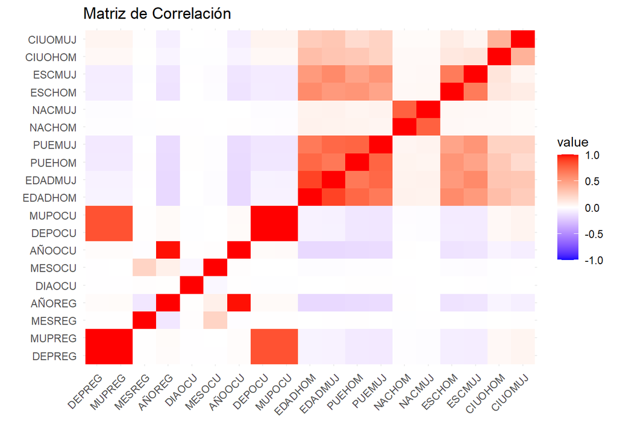

```r
numerical_data <- datos[sapply(datos, is.numeric)]

corr_matrix <- cor(numerical_data, use = "complete.obs")
corr_melted <- melt(corr_matrix)

ggplot(corr_melted, aes(Var1, Var2, fill = value)) +
  geom_tile() +
  scale_fill_gradient2(low = "blue", high = "red", mid = "white", midpoint = 0, limit = c(-1, 1)) +
  theme_minimal() +
  labs(title = "Matriz de Correlación", x = "", y = "") +
  theme(axis.text.x = element_text(angle = 45, hjust = 1))
```